# lec08-working-with-text

```python
import numpy as np
import matplotlib.pyplot as plt
import pandas as pd
import seaborn as sns
import zipfile
%matplotlib inline
```

## Canonicalization

```python
with open('county_and_state.csv') as f:
    county_and_state = pd.read_csv(f)

with open('county_and_population.csv') as f:
    county_and_pop = pd.read_csv(f)
```

Suppose we'd like to join these two tables. Unfortunately, we can't, because the strings representing the county names don't match, as seen below.

```python
county_and_state
```

|  | County | State |
| --- | --- | --- |
| 0 | De Witt County | IL |
| 1 | Lac qui Parle County | MN |
| 2 | Lewis and Clark County | MT |
| 3 | St John the Baptist Parish | LS |

```python
county_and_pop
```

|  | County | Population |
| --- | --- | --- |
| 0 | DeWitt | 16798 |
| 1 | Lac Qui Parle | 8067 |
| 2 | Lewis & Clark | 55716 |
| 3 | St. John the Baptist | 43044 |

Before we can join them, we'll do what I call **canonicalization**.

Canonicalization: A process for converting data that has more than one possible representation into a "standard", "normal", or canonical form (definition via Wikipedia).

```python
def canonicalize_county(county_name):
    return (
        county_name
        .lower()               # lower case
        .replace(' ', '')      # remove spaces
        .replace('&', 'and')   # replace &
        .replace('.', '')      # remove dot
        .replace('county', '') # remove county
        .replace('parish', '') # remove parish
    )
```

```python
county_and_pop['clean_county'] = county_and_pop['County'].map(canonicalize_county)
county_and_state['clean_county'] = county_and_state['County'].map(canonicalize_county)
```

```python
county_and_pop.merge(county_and_state,
                     left_on = 'clean_county', right_on = 'clean_county')
```

|  | County_x | Population | clean_county | County_y | State |
| --- | --- | --- | --- | --- | --- |
| 0 | DeWitt | 16798 | dewitt | De Witt County | IL |
| 1 | Lac Qui Parle | 8067 | lacquiparle | Lac qui Parle County | MN |
| 2 | Lewis & Clark | 55716 | lewisandclark | Lewis and Clark County | MT |
| 3 | St. John the Baptist | 43044 | stjohnthebaptist | St John the Baptist Parish | LS |

## Processing Data from a Text Log Using Basic Python

```python
with open('log.txt', 'r') as f:
    log_lines = f.readlines()
```

```python
log_lines
```

```
['169.237.46.168 - - [26/Jan/2014:10:47:58 -0800] "GET /stat141/Winter04/ HTTP/1.1" 200 2585 "http://anson.ucdavis.edu/courses/"\n',
 '193.205.203.3 - - [2/Feb/2005:17:23:6 -0800] "GET /stat141/Notes/dim.html HTTP/1.0" 404 302 "http://eeyore.ucdavis.edu/stat141/Notes/session.html"\n',
 '169.237.46.240 - "" [3/Feb/2006:10:18:37 -0800] "GET /stat141/homework/Solutions/hw1Sol.pdf HTTP/1.1"\n']
```

Suppose we want to extract the day, month, year, hour, minutes, seconds, and timezone. Looking at the data, we see that these items are not in a fixed position relative to the beginning of the string. That is, slicing by some fixed offset isn't going to work.

```python
log_lines[0][20:31]
```

```
'26/Jan/2014'
```

```python
log_lines[1][20:31]
```

```
'/Feb/2005:1'
```

Instead, we'll need to use some more sophisticated thinking. Let's focus on only the first line of the file.

```python
first = log_lines[0]
first
```

```
'169.237.46.168 - - [26/Jan/2014:10:47:58 -0800] "GET /stat141/Winter04/ HTTP/1.1" 200 2585 "http://anson.ucdavis.edu/courses/"\n'
```

```python
pertinent = first.split("[")[1].split(']')[0]
day, month, rest = pertinent.split('/')
year, hour, minute, rest = rest.split(':')
seconds, time_zone = rest.split(' ')
day, month, year, hour, minute, seconds, time_zone
```

```
('26', 'Jan', '2014', '10', '47', '58', '-0800')
```

A much more sophisticated but common approach is to extract the information we need using a regular expression. See [today's lecture slides](https://docs.google.com/presentation/d/1omFKPsCaPf58VLo33U9ipRq4vt1Kj_3y9yHDUl8qYhk/edit#slide=id.g41d831233f_1_119) for more on regular expressions.

```python
import re
pattern = r'\[(\d+)/(\w+)/(\d+):(\d+):(\d+):(\d+) (.+)\]'
day, month, year, hour, minute, second, time_zone = re.search(pattern, first).groups()
year, month, day, hour, minute, second, time_zone
```

```
('2014', 'Jan', '26', '10', '47', '58', '-0800')
```

Or alternately using the `findall` method:

```python
import re
pattern = r'\[(\d+)/(\w+)/(\d+):(\d+):(\d+):(\d+) (.+)\]'
day, month, year, hour, minute, second, time_zone = re.findall(pattern, first)[0]
year, month, day, hour, minute, second, time_zone
```

```
('2014', 'Jan', '26', '10', '47', '58', '-0800')
```

Note: We can return the results as a Series:

```python
cols = ["Day", "Month", "Year", "Hour", "Minute", "Second", "Time Zone"]
def log_entry_to_series(line):
    return pd.Series(re.search(pattern, line).groups(), index = cols)

log_entry_to_series(first)
```

```
Day             26
Month          Jan
Year          2014
Hour            10
Minute          47
Second          58
Time Zone    -0800
dtype: object
```

And using this function we can create a DataFrame of all the time information.

```python
log_info = pd.DataFrame(columns=cols)

for line in log_lines:
    log_info = log_info.append(log_entry_to_series(line), ignore_index = True)

log_info
```

|  | Day | Month | Year | Hour | Minute | Second | Time Zone |
| --- | --- | --- | --- | --- | --- | --- | --- |
| 0 | 26 | Jan | 2014 | 10 | 47 | 58 | -0800 |
| 1 | 2 | Feb | 2005 | 17 | 23 | 6 | -0800 |
| 2 | 3 | Feb | 2006 | 10 | 18 | 37 | -0800 |

### Regular Expression From Lecture

Fill in the regex below so that after code executes, day is “26”, month is “Jan”, and year is “2014”.

```python
log_lines[0]
```

```
'169.237.46.168 - - [26/Jan/2014:10:47:58 -0800] "GET /stat141/Winter04/ HTTP/1.1" 200 2585 "http://anson.ucdavis.edu/courses/"\n'
```

```python
pattern = r"YOUR REGEX HERE"
matches = re.findall(pattern, log_lines[0])
#day, month, year = matches[0]
#day, month, year
```

## Real World Example #1: Restaurant Data

In this example, we will show how regexes can allow us to track quantitative data across categories defined by the appearance of various text fields.

In this example we'll see how the presence of certain keywords can affect quantitative data, e.g. how do restaurant health scores vary as a function of the number of violations that mention "vermin"?

```python
vio = pd.read_csv('violations.csv', header=0, names=['id', 'date', 'desc'])
desc = vio['desc']
vio.head()
```

|  | id | date | desc |
| --- | --- | --- | --- |
| 0 | 19 | 20171211 | Inadequate food safety knowledge or lack of ce... |
| 1 | 19 | 20171211 | Unapproved or unmaintained equipment or utensils |
| 2 | 19 | 20160513 | Unapproved or unmaintained equipment or utensi... |
| 3 | 19 | 20160513 | Unclean or degraded floors walls or ceilings ... |
| 4 | 19 | 20160513 | Food safety certificate or food handler card n... |

```python
counts = desc.value_counts()

counts[:10]
```

```
Unclean or degraded floors walls or ceilings                          999
Unapproved or unmaintained equipment or utensils                      659
Inadequately cleaned or sanitized food contact surfaces               493
Improper food storage                                                 476
Inadequate and inaccessible handwashing facilities                    467
Moderate risk food holding temperature                                452
Wiping cloths not clean or properly stored or inadequate sanitizer    418
Moderate risk vermin infestation                                      374
Unclean nonfood contact surfaces                                      369
Food safety certificate or food handler card not available            353
Name: desc, dtype: int64
```

```python
# Hmmm...
counts[50:60]
```

```
Moderate risk food holding temperature   [ date violation corrected: 10/11/2016 ]                   16
Unclean or degraded floors walls or ceilings  [ date violation corrected: 11/29/2017 ]              16
Unclean or degraded floors walls or ceilings  [ date violation corrected: 9/19/2017 ]               16
Unclean or degraded floors walls or ceilings  [ date violation corrected: 11/27/2017 ]              15
Unclean or degraded floors walls or ceilings  [ date violation corrected: 12/7/2017 ]               15
Unclean or degraded floors walls or ceilings  [ date violation corrected: 9/6/2017 ]                14
Unapproved or unmaintained equipment or utensils  [ date violation corrected: 9/19/2017 ]           14
Inadequately cleaned or sanitized food contact surfaces  [ date violation corrected: 9/26/2017 ]    14
Unclean or degraded floors walls or ceilings  [ date violation corrected: 11/28/2017 ]              14
Unclean or degraded floors walls or ceilings  [ date violation corrected: 10/31/2017 ]              13
Name: desc, dtype: int64
```

```python
#Use regular expressions to cut out the extra info in square braces.
vio['clean_desc'] = (vio['desc']
             .str.replace('\s*\[.*\]$', '')
             .str.strip()
             .str.lower())
vio.head()
```

|  | id | date | desc | clean_desc |
| --- | --- | --- | --- | --- |
| 0 | 19 | 20171211 | Inadequate food safety knowledge or lack of ce... | inadequate food safety knowledge or lack of ce... |
| 1 | 19 | 20171211 | Unapproved or unmaintained equipment or utensils | unapproved or unmaintained equipment or utensils |
| 2 | 19 | 20160513 | Unapproved or unmaintained equipment or utensi... | unapproved or unmaintained equipment or utensils |
| 3 | 19 | 20160513 | Unclean or degraded floors walls or ceilings ... | unclean or degraded floors walls or ceilings |
| 4 | 19 | 20160513 | Food safety certificate or food handler card n... | food safety certificate or food handler card n... |

```python
vio['clean_desc'].value_counts().head()
```

```
unclean or degraded floors walls or ceilings               3507
moderate risk food holding temperature                     2542
inadequate and inaccessible handwashing facilities         2529
unapproved or unmaintained equipment or utensils           2382
inadequately cleaned or sanitized food contact surfaces    2301
Name: clean_desc, dtype: int64
```

```python
#use regular expressions to assign new features for the presence of various keywords
with_features = (vio
 .assign(is_clean     = vio['clean_desc'].str.contains('clean|sanit'))
 .assign(is_high_risk = vio['clean_desc'].str.contains('high risk'))
 .assign(is_vermin    = vio['clean_desc'].str.contains('vermin'))
 .assign(is_surface   = vio['clean_desc'].str.contains('wall|ceiling|floor|surface'))
 .assign(is_human     = vio['clean_desc'].str.contains('hand|glove|hair|nail'))
 .assign(is_permit    = vio['clean_desc'].str.contains('permit|certif'))
)
with_features.head()
```

|  | id | date | desc | clean_desc | is_clean | is_high_risk | is_vermin | is_surface | is_human | is_permit |
| --- | --- | --- | --- | --- | --- | --- | --- | --- | --- | --- |
| 0 | 19 | 20171211 | Inadequate food safety knowledge or lack of ce... | inadequate food safety knowledge or lack of ce... | False | False | False | False | False | True |
| 1 | 19 | 20171211 | Unapproved or unmaintained equipment or utensils | unapproved or unmaintained equipment or utensils | False | False | False | False | False | False |
| 2 | 19 | 20160513 | Unapproved or unmaintained equipment or utensi... | unapproved or unmaintained equipment or utensils | False | False | False | False | False | False |
| 3 | 19 | 20160513 | Unclean or degraded floors walls or ceilings ... | unclean or degraded floors walls or ceilings | True | False | False | True | False | False |
| 4 | 19 | 20160513 | Food safety certificate or food handler card n... | food safety certificate or food handler card n... | False | False | False | False | True | True |

```python
count_features = (with_features
 .groupby(['id', 'date'])
 .sum()
 .reset_index()
)
count_features.iloc[255:260, :]
```

|  | id | date | is_clean | is_high_risk | is_vermin | is_surface | is_human | is_permit |
| --- | --- | --- | --- | --- | --- | --- | --- | --- |
| 255 | 489 | 20150728 | 5.0 | 0.0 | 2.0 | 3.0 | 0.0 | 0.0 |
| 256 | 489 | 20150807 | 1.0 | 0.0 | 0.0 | 1.0 | 0.0 | 0.0 |
| 257 | 489 | 20160308 | 2.0 | 2.0 | 1.0 | 0.0 | 1.0 | 0.0 |
| 258 | 489 | 20160721 | 2.0 | 1.0 | 1.0 | 1.0 | 0.0 | 1.0 |
| 259 | 489 | 20161220 | 3.0 | 0.0 | 1.0 | 2.0 | 0.0 | 0.0 |

```python
count_features.query('is_vermin > 1')
```

|  | id | date | is_clean | is_high_risk | is_vermin | is_surface | is_human | is_permit |
| --- | --- | --- | --- | --- | --- | --- | --- | --- |
| 255 | 489 | 20150728 | 5.0 | 0.0 | 2.0 | 3.0 | 0.0 | 0.0 |
| 291 | 527 | 20170821 | 1.0 | 1.0 | 2.0 | 1.0 | 1.0 | 1.0 |
| 1508 | 2622 | 20160526 | 4.0 | 2.0 | 2.0 | 3.0 | 0.0 | 0.0 |
| 1573 | 2721 | 20150422 | 2.0 | 1.0 | 2.0 | 1.0 | 0.0 | 0.0 |
| 1746 | 2945 | 20150921 | 2.0 | 1.0 | 2.0 | 2.0 | 2.0 | 1.0 |
| 2277 | 3776 | 20151223 | 2.0 | 0.0 | 2.0 | 1.0 | 0.0 | 0.0 |
| 3784 | 6729 | 20160706 | 6.0 | 0.0 | 2.0 | 4.0 | 2.0 | 0.0 |
| 3949 | 7537 | 20150304 | 1.0 | 0.0 | 2.0 | 1.0 | 1.0 | 0.0 |
| 4017 | 7661 | 20160616 | 2.0 | 0.0 | 2.0 | 2.0 | 1.0 | 0.0 |
| 4165 | 9679 | 20150422 | 2.0 | 0.0 | 2.0 | 2.0 | 0.0 | 0.0 |
| 7742 | 69353 | 20150420 | 3.0 | 1.0 | 2.0 | 2.0 | 1.0 | 0.0 |
| 8319 | 71999 | 20150401 | 1.0 | 1.0 | 2.0 | 0.0 | 0.0 | 0.0 |
| 9074 | 77427 | 20170706 | 0.0 | 0.0 | 2.0 | 0.0 | 0.0 | 0.0 |
| 9759 | 80112 | 20160225 | 2.0 | 0.0 | 2.0 | 0.0 | 0.0 | 2.0 |
| 11552 | 87492 | 20161208 | 6.0 | 2.0 | 2.0 | 4.0 | 2.0 | 0.0 |

```python
#use a new pandas feature called "melt" that we won't describe in any detail
#the granularity of the resulting frame is a violation type in a given inspection
broken_down_by_violation_type = pd.melt(count_features, id_vars=['id', 'date'],
            var_name='feature', value_name='num_vios')
broken_down_by_violation_type.sort_values(["id", "date"]).head(13)
```

|  | id | date | feature | num_vios |
| --- | --- | --- | --- | --- |
| 0 | 19 | 20160513 | is_clean | 1.0 |
| 12262 | 19 | 20160513 | is_high_risk | 0.0 |
| 24524 | 19 | 20160513 | is_vermin | 0.0 |
| 36786 | 19 | 20160513 | is_surface | 1.0 |
| 49048 | 19 | 20160513 | is_human | 1.0 |
| 61310 | 19 | 20160513 | is_permit | 1.0 |
| 1 | 19 | 20171211 | is_clean | 0.0 |
| 12263 | 19 | 20171211 | is_high_risk | 0.0 |
| 24525 | 19 | 20171211 | is_vermin | 0.0 |
| 36787 | 19 | 20171211 | is_surface | 0.0 |
| 49049 | 19 | 20171211 | is_human | 0.0 |
| 61311 | 19 | 20171211 | is_permit | 1.0 |
| 2 | 24 | 20160311 | is_clean | 2.0 |

```python
#read in the scores
ins = pd.read_csv('inspections.csv',
                  header=0,
                  usecols=[0, 1, 2],
                  names=['id', 'score', 'date'])
ins.head()
```

|  | id | score | date |
| --- | --- | --- | --- |
| 0 | 19 | 94 | 20160513 |
| 1 | 19 | 94 | 20171211 |
| 2 | 24 | 98 | 20171101 |
| 3 | 24 | 98 | 20161005 |
| 4 | 24 | 96 | 20160311 |

```python
#join scores with the table broken down by violation type
violation_type_and_scores = (
    broken_down_by_violation_type
    .merge(ins, left_on=['id', 'date'], right_on=['id', 'date'])
)
violation_type_and_scores.head(12)
```

|  | id | date | feature | num_vios | score |
| --- | --- | --- | --- | --- | --- |
| 0 | 19 | 20160513 | is_clean | 1.0 | 94 |
| 1 | 19 | 20160513 | is_high_risk | 0.0 | 94 |
| 2 | 19 | 20160513 | is_vermin | 0.0 | 94 |
| 3 | 19 | 20160513 | is_surface | 1.0 | 94 |
| 4 | 19 | 20160513 | is_human | 1.0 | 94 |
| 5 | 19 | 20160513 | is_permit | 1.0 | 94 |
| 6 | 19 | 20171211 | is_clean | 0.0 | 94 |
| 7 | 19 | 20171211 | is_high_risk | 0.0 | 94 |
| 8 | 19 | 20171211 | is_vermin | 0.0 | 94 |
| 9 | 19 | 20171211 | is_surface | 0.0 | 94 |
| 10 | 19 | 20171211 | is_human | 0.0 | 94 |
| 11 | 19 | 20171211 | is_permit | 1.0 | 94 |

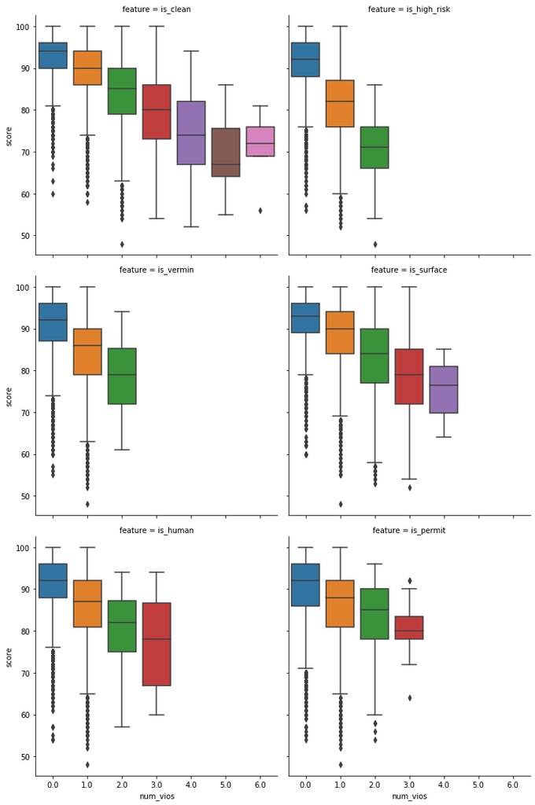

```python
sns.catplot(x='num_vios', y='score',
               col='feature', col_wrap=2,
               kind='box',
               data=violation_type_and_scores)
```

Above we see, for example, that if a restaurant inspection involved 2 violation with the keyword "vermin", the average score for that inspection would be a little bit below 80.

## Text Processing Example 2: Police Data

In this example, we will apply string processing to the process of data cleaning and exploratory data analysis.

### Getting the Data

The city of Berkeley maintains an [Open Data Portal](https://data.cityofberkeley.info/) for citizens to access data about the city. We will be examining [Call Data](https://data.cityofberkeley.info/Public-Safety/Berkeley-PD-Calls-for-Service/k2nh-s5h5).

[figure not shown]

```python
import ds100_utils

calls_url = 'https://data.cityofberkeley.info/api/views/k2nh-s5h5/rows.csv?accessType=DOWNLOAD'
calls_file = ds100_utils.fetch_and_cache(calls_url, 'calls.csv')
calls = pd.read_csv(calls_file, warn_bad_lines=True)
calls.head()
```

```
Downloading... Done!
```

|  | CASENO | OFFENSE | EVENTDT | EVENTTM | CVLEGEND | CVDOW | InDbDate | Block_Location | BLKADDR | City | State |
| --- | --- | --- | --- | --- | --- | --- | --- | --- | --- | --- | --- |
| 0 | 19042350 | BURGLARY AUTO | 08/01/2019 12:00:00 AM | 14:00 | BURGLARY - VEHICLE | 4 | 07/01/2020 07:00:09 AM | CURTIS STREET &STANNAGE AVE\nBerkeley, CA | CURTIS STREET &STANNAGE AVE | Berkeley | CA |
| 1 | 19091711 | VANDALISM | 08/19/2019 12:00:00 AM | 22:00 | VANDALISM | 1 | 07/01/2020 07:00:10 AM | CALIFORNIA STREET & FAIRVIEW ST\nBerkeley, CA | CALIFORNIA STREET & FAIRVIEW ST | Berkeley | CA |
| 2 | 19042731 | VEHICLE STOLEN | 08/03/2019 12:00:00 AM | 15:30 | MOTOR VEHICLE THEFT | 6 | 07/01/2020 07:00:09 AM | 1300 WALNUT ST\nBerkeley, CA\n(37.883798, -122... | 1300 WALNUT ST | Berkeley | CA |
| 3 | 19092546 | BURGLARY AUTO | 11/09/2019 12:00:00 AM | 09:00 | BURGLARY - VEHICLE | 6 | 07/01/2020 07:00:13 AM | CLAREMONT AVE&STONEWALL ROAD AVE\nBerkeley, CA | CLAREMONT AVE&STONEWALL ROAD AVE | Berkeley | CA |
| 4 | 19043231 | SEXUAL ASSAULT FEL. | 08/04/2019 12:00:00 AM | 00:00 | SEX CRIME | 0 | 07/01/2020 07:00:10 AM | <UNKNOWN>\nBerkeley, CA | <UNKNOWN> | Berkeley | CA |

How many records did we get?

```python
len(calls)
```

```
5227
```

What does an example `Block_Location` value look like?

```python
print(calls['Block_Location'].iloc[0])
```

```
CURTIS STREET &STANNAGE AVE
Berkeley, CA
```

### Preliminary observations on the data?

1. `EVENTDT` -- Contains the incorrect time
2. `EVENTTM` -- Contains the time in 24 hour format (What timezone?)
3. `CVDOW` -- Encodes the day of the week (see data documentation).
4. `InDbDate` -- Appears to be correctly formatted and appears pretty consistent in time.
5. **`Block_Location` -- a multi-line string that contains coordinates.**
6. `BLKADDR` -- Appears to be the address in `Block Location`.
7. `City` and `State` seem redundant given this is supposed to be the city of Berkeley dataset.

### Extracting locations

The block location contains geographic coordinates. Let's extract them.

```python
calls['Block_Location'][0]
```

```
'CURTIS STREET &STANNAGE AVE\nBerkeley, CA'
```

```python
calls_lat_lon = (
    calls['Block_Location']
    .str.extract("\((\d+\.\d+)\, (-\d+\.\d+)\)")
)
calls_lat_lon.columns = ['Lat', 'Lon']
calls_lat_lon.head(10)
```

|  | Lat | Lon |
| --- | --- | --- |
| 0 | NaN | NaN |
| 1 | NaN | NaN |
| 2 | 37.883798 | -122.268567 |
| 3 | NaN | NaN |
| 4 | NaN | NaN |
| 5 | NaN | NaN |
| 6 | NaN | NaN |
| 7 | NaN | NaN |
| 8 | NaN | NaN |
| 9 | 37.86695 | -122.286984 |

How many records have missing values?

```python
calls_lat_lon.isnull().sum()
```

```
Lat    193
Lon    193
dtype: int64
```

Examine the missing values.

```python
calls[calls_lat_lon.isnull().any(axis=1)]['Block_Location'].head(10)
```

```
0          CURTIS STREET &STANNAGE AVE\nBerkeley, CA
1      CALIFORNIA STREET & FAIRVIEW ST\nBerkeley, CA
3     CLAREMONT AVE&STONEWALL ROAD AVE\nBerkeley, CA
4                            <UNKNOWN>\nBerkeley, CA
5            ADDISON STREET & GRANT ST\nBerkeley, CA
6                       800 BOLIVAR DR\nBerkeley, CA
7                            MILVIA ST\nBerkeley, CA
8           SHATTUCK AV & TELEGRAPH AV\nBerkeley, CA
10              2016 BERKELEY WAY PATH\nBerkeley, CA
17                         BERRYMAN ST\nBerkeley, CA
Name: Block_Location, dtype: object
```

Join in the extracted values.

```python
calls['Lat'] = calls_lat_lon['Lat']
calls['Lon'] = calls_lat_lon['Lon']
calls.head()
```

|  | CASENO | OFFENSE | EVENTDT | EVENTTM | CVLEGEND | CVDOW | InDbDate | Block_Location | BLKADDR | City | State | Lat | Lon |
| --- | --- | --- | --- | --- | --- | --- | --- | --- | --- | --- | --- | --- | --- |
| 0 | 19042350 | BURGLARY AUTO | 08/01/2019 12:00:00 AM | 14:00 | BURGLARY - VEHICLE | 4 | 07/01/2020 07:00:09 AM | CURTIS STREET &STANNAGE AVE\nBerkeley, CA | CURTIS STREET &STANNAGE AVE | Berkeley | CA | NaN | NaN |
| 1 | 19091711 | VANDALISM | 08/19/2019 12:00:00 AM | 22:00 | VANDALISM | 1 | 07/01/2020 07:00:10 AM | CALIFORNIA STREET & FAIRVIEW ST\nBerkeley, CA | CALIFORNIA STREET & FAIRVIEW ST | Berkeley | CA | NaN | NaN |
| 2 | 19042731 | VEHICLE STOLEN | 08/03/2019 12:00:00 AM | 15:30 | MOTOR VEHICLE THEFT | 6 | 07/01/2020 07:00:09 AM | 1300 WALNUT ST\nBerkeley, CA\n(37.883798, -122... | 1300 WALNUT ST | Berkeley | CA | 37.883798 | -122.268567 |
| 3 | 19092546 | BURGLARY AUTO | 11/09/2019 12:00:00 AM | 09:00 | BURGLARY - VEHICLE | 6 | 07/01/2020 07:00:13 AM | CLAREMONT AVE&STONEWALL ROAD AVE\nBerkeley, CA | CLAREMONT AVE&STONEWALL ROAD AVE | Berkeley | CA | NaN | NaN |
| 4 | 19043231 | SEXUAL ASSAULT FEL. | 08/04/2019 12:00:00 AM | 00:00 | SEX CRIME | 0 | 07/01/2020 07:00:10 AM | <UNKNOWN>\nBerkeley, CA | <UNKNOWN> | Berkeley | CA | NaN | NaN |

## Examining Location information

Let's examine the geographic data (latitude and longitude). Recall that we had some missing values. Let's look at the behavior of these missing values according to crime type.

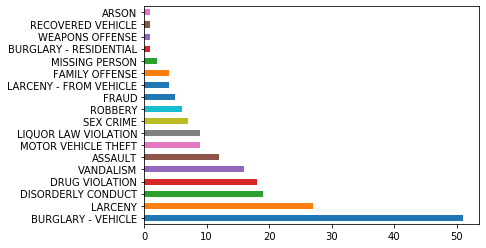

```python
missing_lat_lon = calls[calls[['Lat', 'Lon']].isnull().any(axis=1)]
missing_lat_lon['CVLEGEND'].value_counts().plot(kind='barh');
```

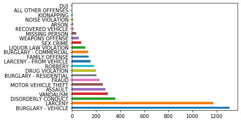

```python
calls['CVLEGEND'].value_counts().plot(kind='barh');
```

We might further normalize the analysis by the frequency to find which type of crime has the highest proportion of missing values.

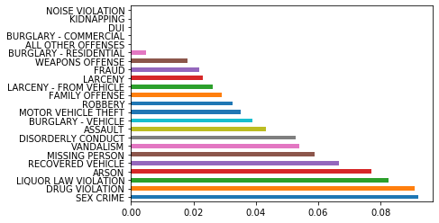

```python
(missing_lat_lon['CVLEGEND'].value_counts()
 / calls['CVLEGEND'].value_counts()
).sort_values(ascending=False).plot(kind="barh");
```

Now, let's make a crime map.

```python
# you may need to install the folium package for this to work
# to do this, uncomment the line below and run it.
# !pip install folium
```

```python
import folium
import folium.plugins

SF_COORDINATES = (37.87, -122.28)
sf_map = folium.Map(location=SF_COORDINATES, zoom_start=13)
locs = calls[['Lat', 'Lon']].astype('float').dropna().values
heatmap = folium.plugins.HeatMap(locs.tolist(), radius=10)
sf_map.add_child(heatmap)
```

Make this Notebook Trusted to load map: File -> Trust Notebook

[interactive chart not shown]

### Questions

1. Is campus really the safest place to be?
2. Why are all the calls located on the street and at often at intersections?

```python
import folium.plugins

locations = calls[calls['CVLEGEND'] == 'ASSAULT'][['Lat', 'Lon']]

cluster = folium.plugins.MarkerCluster()
for _, r in locations.dropna().iterrows():
    cluster.add_child(
        folium.Marker([float(r["Lat"]), float(r["Lon"])]))

sf_map = folium.Map(location=SF_COORDINATES, zoom_start=13)
sf_map.add_child(cluster)
sf_map
```

Make this Notebook Trusted to load map: File -> Trust Notebook

[interactive chart not shown]

## Bonus Content: Using pd.to_datetime to Extract Time Information

Date parsing using `pd.to_datetime`.

```python
pd.Series(log_lines).str.extract(r'\[(.*) -0800\]').apply(
    lambda s: pd.to_datetime(s, format='%d/%b/%Y:%H:%M:%S'))
```

|  | 0 |
| --- | --- |
| 0 | 2014-01-26 10:47:58 |
| 1 | 2005-02-02 17:23:06 |
| 2 | 2006-02-03 10:18:37 |